# Two Variables: Quantitative and Qualitative

Author

Freda B. Langpawan

Published

November 13, 2026

# The Data

```r
# install packages: install.packages("package")
# load packages
library(tidyverse)
library(knitr)
library(gtsummary)
library(ggstatsplot)
library(downlit)
library(broom)
library(car)
library(here)

# load the data
df <- read_csv(here("Data", "my_dataset.csv"))

df <- df |>
  mutate(
    SleepDur = factor(
      `Sleep Dur`,
      levels = c("Less than 4 hours", "4-5 hours", "6-7 hours", "8-9 hours", "More than 9 hours"),
      ordered = TRUE
    )
  ) |>
  select(
    SleepDur,
    `DailyPerf`
  )
```

## Sleep-Productivity Test

The dataset consists of 68 respondents from Nueva Vizcaya State University (NVSU).Two variables are considered which are Sleep Duration and Daily Productivity. Sleep duration refers to the number of hours students usually sleep at night, grouped into different categories, while daily productivity measures how students rate their productivity on a scale of 1 to 10.

```r
df|> # call the data
  head() |> # get the first six rows of the data
  kable(col.names= c("Sleep Duration", "Daily Productivity")) # create a table
```

Table 1: The first 6 observations of the data set.

| Sleep Duration | Daily Productivity |
| --- | --- |
| 6-7 hours | 5 |
| 8-9 hours | 5 |
| 8-9 hours | 8 |
| More than 9 hours | 7 |
| 8-9 hours | 8 |
| 6-7 hours | 4 |

## Descriptive Statistics

```r
df|> # call the data
  tbl_summary( # create a table
    by = SleepDur, # grouping
    include = DailyPerf, # select variables
    statistic = all_continuous() ~ "{mean} ± {sd} ({min} - {max})", # descriptive statistics
    digits = all_continuous() ~ 2 # no. of digits (rounding)
  )
```

Table 2: Summary statistics of DailyPerf when grouped according to SleepDur.

| **Characteristic** | **Less than 4 hours** N = 7<sup>1</sup> | **4-5 hours** N = 9<sup>1</sup> | **6-7 hours** N = 32<sup>1</sup> | **8-9 hours** N = 16<sup>1</sup> | **More than 9 hours** N = 4<sup>1</sup> |
| --- | --- | --- | --- | --- | --- |
| DailyPerf |  |  |  |  |  |
| 1 | 0 (0%) | 0 (0%) | 0 (0%) | 1 (6.3%) | 0 (0%) |
| 3 | 1 (14%) | 0 (0%) | 2 (6.3%) | 1 (6.3%) | 0 (0%) |
| 4 | 0 (0%) | 2 (22%) | 3 (9.4%) | 1 (6.3%) | 1 (25%) |
| 5 | 1 (14%) | 0 (0%) | 7 (22%) | 2 (13%) | 0 (0%) |
| 6 | 1 (14%) | 2 (22%) | 6 (19%) | 0 (0%) | 1 (25%) |
| 7 | 1 (14%) | 1 (11%) | 7 (22%) | 4 (25%) | 1 (25%) |
| 8 | 2 (29%) | 4 (44%) | 2 (6.3%) | 5 (31%) | 1 (25%) |
| 9 | 0 (0%) | 0 (0%) | 3 (9.4%) | 1 (6.3%) | 0 (0%) |
| 10 | 1 (14%) | 0 (0%) | 2 (6.3%) | 1 (6.3%) | 0 (0%) |

<sup>1</sup> n (%)

# Hypothesis Testing

### Research Question

Is there a significant difference in Daily Productivity when grouped according to Sleep Duration?

### Hypothesis and Test Statistics

```r
df_levene <- df |> # call the data
  mutate(
  SleepDur= factor(
    SleepDur),
    DailyPerf= as.numeric(DailyPerf),
    )


leveneTest(DailyPerf ~ SleepDur, data = df_levene, center = mean) |>
  tidy() |>
  mutate(across(where(is.numeric), ~ round(.x, 2))) |>
  kable()
```

Table 3: Levene’s test for homogeneity of variance.

| statistic | p.value | df | df.residual |
| --- | --- | --- | --- |
| 0.45 | 0.77 | 4 | 63 |

```r
df_levene |>
  group_by(SleepDur) |>
  summarise(
    tidy(shapiro.test(DailyPerf)),
    .groups = "drop"
  ) |>
  mutate(across(where(is.numeric), ~ round(.x, 2))) |>
  kable()
```

Table 4: Shapiro-Wilk normality test.

| SleepDur | statistic | p.value | method |
| --- | --- | --- | --- |
| Less than 4 hours | 0.98 | 0.96 | Shapiro-Wilk normality test |
| 4-5 hours | 0.81 | 0.03 | Shapiro-Wilk normality test |
| 6-7 hours | 0.95 | 0.20 | Shapiro-Wilk normality test |
| 8-9 hours | 0.90 | 0.09 | Shapiro-Wilk normality test |
| More than 9 hours | 0.97 | 0.85 | Shapiro-Wilk normality test |

### Results and Interpretation

The plot and test statistics is shown on Figure 1.

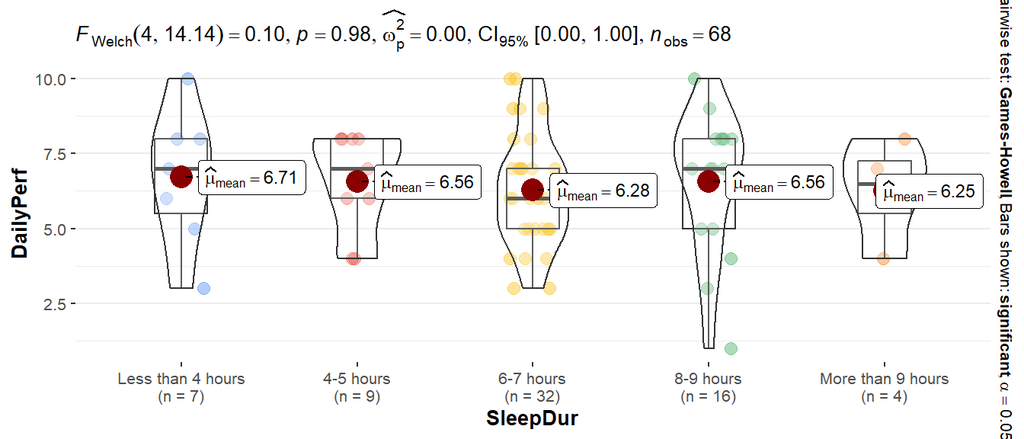

Figure 1: Comparison of DailyPerf by SleepDur.

```r
df_levene |> # call the cleaned data
  ggbetweenstats(
    x = SleepDur,
    y = DailyPerf,
    plot.type = "box", # for boxplot
    type = "parametric", # for Welch's ANOVA
    var.equal = FALSE, # unequal variances
    centrality.plotting = TRUE
  ) +
  labs(caption = NULL) # remove caption
```

Based on the plot and the *p-value being greater than 5% (FWelch(4, 14.14) = 0.10, p-value = 0.98), we fail to reject the null hypothesis. There is no sufficient evidence to conclude that the mean Daily Performance is different when grouped according to Sleep Duration. Across all five sleep duration categories, the average daily performance scores remain very similar (ranging only from 6.25 to 6.71), indicating that sleep duration does not significantly affect daily performance in this sample*.